# Deep Learning- 課程 12－Deep Learning- Using Pre-Trained Vgg16 Convnets Model - Training New Model - Python Tutorial

''' >> 移花+接木 '''

```python
from keras import models
from keras import layers

model = models.Sequential()                       # 產生一個新的網絡模型結構
model.add(conv_base)                              # 把預訓練的卷積基底疊上去
model.add(layers.Flatten())                       # 打平
model.add(layers.Dense(256, activation='relu'))   # 疊上新的密集連接層來做為分類器
model.add(layers.Dense(1, activation='sigmoid'))  # 因為資料集只有 - 兩類(Cat & Dog)
```

這是我們現在的模型：

```python
model.summary()
```

```
_________________________________________________________________
Layer (type)                 Output Shape              Param #
=================================================================
vgg16 (Model)                (None, 4, 4, 512)         14714688
_________________________________________________________________
flatten_1 (Flatten)          (None, 8192)              0
_________________________________________________________________
dense_5 (Dense)              (None, 256)               2097408
_________________________________________________________________
dense_6 (Dense)              (None, 1)                 257
=================================================================
Total params: 16,812,353
Trainable params: 16,812,353
Non-trainable params: 0
_________________________________________________________________
```

''' - VGG16 的 - 卷積基底 - - 14,714,688個參數，這非常大 - 上面添加的分類器 - 2097408 萬 - 參數 Parameters - 在編譯和訓練我們的模型之前 - 一個非常重要的事情是凍結 - 卷積基底 - >> 凍結 一層或多層圖層意味著在訓練期間防止其權重被更新 - 如果不這樣做 - 那麼以前在 - 卷積基底 - 上 - 學到的特徵將在訓練期間被修改 >> 由於頂層的 - Dense Layer - 層會被隨機初始化 - 因此非常大的權重更新將通過網絡重新進行傳播 - 也會破壞以前學習的結果。 - 在Keras中 - 通過 -trainable - 的屬性設置 - 為 - False 來凍結網絡 '''

```python
# 凍結前 - 卷積基底 有多少可以被訓練的權重

print('This is the number of trainable weights '
      'before freezing the conv base:', len(model.trainable_weights))
```

```
This is the number of trainable weights before freezing the conv base: 30
```

```python
# 凍結

conv_base.trainable = False
```

```python
# 凍結後 - 卷積基底 有多少可以被訓練的權重

print('This is the number of trainable weights '
      'after freezing the conv base:', len(model.trainable_weights))
```

```
This is the number of trainable weights after freezing the conv base: 4
```

''' >> 通過這種設置， - 只有 添加的兩個 - Dense Layer 層的權重將被訓練 - 這是總共有四個權重 的張量 - 每層兩個 - 主要 - 權重矩陣 Wieghts - 偏差向量 Bias - 必須首先編譯 Compile Model 模型 - 數據增強配置 - 數據擴充 ( Data Augmentation ) '''

```python
%%time

from keras.preprocessing.image import ImageDataGenerator

train_datagen = ImageDataGenerator(
      rescale=1./255,
      rotation_range=40,
      width_shift_range=0.2,
      height_shift_range=0.2,
      shear_range=0.2,
      zoom_range=0.2,
      horizontal_flip=True,
      fill_mode='nearest')

# 驗證的資料 - 不要進行 資料的增強

test_datagen = ImageDataGenerator(rescale=1./255)

train_generator = train_datagen.flow_from_directory(
        # 圖像資料 - 的目錄
        train_dir,
        # 設定圖像的 高( Height ) 與 寬( Width )
        target_size=(150, 150),
        batch_size=20,
        # 因為 - 目標資料集只有兩類(cat & dog)
        class_mode='binary')

validation_generator = test_datagen.flow_from_directory(
        validation_dir,
        target_size=(150, 150),
        batch_size=20,
        class_mode='binary')

model.compile(loss='binary_crossentropy',
              optimizer=optimizers.RMSprop(lr=2e-5),
              metrics=['acc'])

history = model.fit_generator(
      train_generator,
      steps_per_epoch=100,
      epochs=30,
      validation_data=validation_generator,
      validation_steps=50,
      verbose=2)
```

```
Found 2000 images belonging to 2 classes.
Found 1000 images belonging to 2 classes.
 - 181s - loss: 0.6133 - acc: 0.6700 - val_loss: 0.4690 - val_acc: 0.8200
 - 178s - loss: 0.4963 - acc: 0.7770 - val_loss: 0.3851 - val_acc: 0.8430
 - 179s - loss: 0.4362 - acc: 0.8190 - val_loss: 0.3390 - val_acc: 0.8580
 - 179s - loss: 0.4039 - acc: 0.8270 - val_loss: 0.3096 - val_acc: 0.8760
 - 178s - loss: 0.3895 - acc: 0.8270 - val_loss: 0.2965 - val_acc: 0.8750
 - 179s - loss: 0.3712 - acc: 0.8320 - val_loss: 0.2925 - val_acc: 0.8700
 - 179s - loss: 0.3614 - acc: 0.8410 - val_loss: 0.2754 - val_acc: 0.8880
 - 179s - loss: 0.3536 - acc: 0.8435 - val_loss: 0.2694 - val_acc: 0.8870
 - 179s - loss: 0.3517 - acc: 0.8485 - val_loss: 0.2632 - val_acc: 0.8860
 - 178s - loss: 0.3328 - acc: 0.8545 - val_loss: 0.2632 - val_acc: 0.8860
 - 179s - loss: 0.3361 - acc: 0.8605 - val_loss: 0.2578 - val_acc: 0.8860
 - 180s - loss: 0.3229 - acc: 0.8560 - val_loss: 0.2526 - val_acc: 0.8910
 - 178s - loss: 0.3145 - acc: 0.8670 - val_loss: 0.2583 - val_acc: 0.8940
 - 178s - loss: 0.3217 - acc: 0.8620 - val_loss: 0.2558 - val_acc: 0.8970
 - 179s - loss: 0.3158 - acc: 0.8610 - val_loss: 0.2483 - val_acc: 0.8950
 - 179s - loss: 0.3060 - acc: 0.8695 - val_loss: 0.2572 - val_acc: 0.8860
 - 178s - loss: 0.3074 - acc: 0.8660 - val_loss: 0.2435 - val_acc: 0.8980
 - 178s - loss: 0.3070 - acc: 0.8690 - val_loss: 0.2440 - val_acc: 0.9000
 - 178s - loss: 0.2976 - acc: 0.8740 - val_loss: 0.2421 - val_acc: 0.9020
 - 179s - loss: 0.3061 - acc: 0.8650 - val_loss: 0.2441 - val_acc: 0.9020
 - 178s - loss: 0.3042 - acc: 0.8655 - val_loss: 0.2435 - val_acc: 0.8990
 - 178s - loss: 0.3018 - acc: 0.8710 - val_loss: 0.2513 - val_acc: 0.8930
 - 179s - loss: 0.3010 - acc: 0.8680 - val_loss: 0.2447 - val_acc: 0.8950
 - 178s - loss: 0.2892 - acc: 0.8735 - val_loss: 0.2442 - val_acc: 0.8990
 - 179s - loss: 0.3123 - acc: 0.8550 - val_loss: 0.2379 - val_acc: 0.9060
 - 179s - loss: 0.2885 - acc: 0.8735 - val_loss: 0.2419 - val_acc: 0.8990
 - 182s - loss: 0.2802 - acc: 0.8840 - val_loss: 0.2390 - val_acc: 0.9040
 - 178s - loss: 0.2740 - acc: 0.8865 - val_loss: 0.2382 - val_acc: 0.9040
 - 179s - loss: 0.2729 - acc: 0.8755 - val_loss: 0.2541 - val_acc: 0.8930
 - 179s - loss: 0.2714 - acc: 0.8980 - val_loss: 0.2403 - val_acc: 0.9030
Wall time: 1h 29min 22s
```

```python
# 模型 儲存 Model Save

model.save('cats_and_dogs_small_3.h5')
```

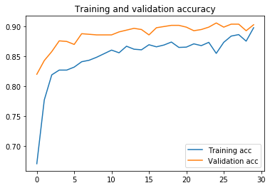

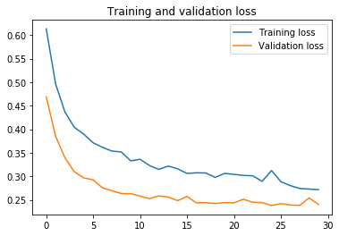

```python
acc = history.history['acc']
val_acc = history.history['val_acc']
loss = history.history['loss']
val_loss = history.history['val_loss']

epochs = range(len(acc))

plt.plot(epochs, acc, label='Training acc')
plt.plot(epochs, val_acc, label='Validation acc')
plt.title('Training and validation accuracy')
plt.legend()

plt.figure()

plt.plot(epochs, loss, label='Training loss')
plt.plot(epochs, val_loss, label='Validation loss')
plt.title('Training and validation loss')
plt.legend()

plt.show()
```

''' >> 微調 (Fine-Tuning) - 模型重覆利用技術，與特徵提取( Feature Extraction ) 相輔相成 - (微調) Fine-Tuning - 微調 - 包括解凍用於特徵提取的凍結模型庫中的幾個頂層 (Top Layers) - 並且共同訓練新添加的模型部分 - - 範例中 - 是完全連接 FC 的分類器 - 這些頂層 - 稱為 微調( Fine-Tuning) - '''

[figure not shown]

''' - 凍結 VGG16 - 卷積基底 - - 在上面訓練一個隨機初始化的分類器 - 一旦分類器已經被訓練，只能微調 - 卷積基底 -的頂層 - 如果分類尚未被訓練 - 則在訓練期間通過網絡傳播的誤差信號將會變得太大 - 並且被微調那些神經層先前學習的表示(Representation) - 將被破壞 - 微調網絡的步驟如下： - 1. 將自定義網絡添加到已經訓練好的基底網絡之上 - 2. 凍結基底網絡 - 3. 訓練您添加的部分 - 4. 解凍基底網絡中的一些神經層 - 5. 共同訓練這些層和您添加的部分 - 在進行特徵提取時 - 已經完成了 - 前3個步驟 - 繼續第四步 - 將解凍 - conv_base - - 然後凍結 - 其中的某些特定的層 '''

```python
conv_base.summary()
```

```
_________________________________________________________________
Layer (type)                 Output Shape              Param #
=================================================================
input_2 (InputLayer)         (None, 150, 150, 3)       0
_________________________________________________________________
block1_conv1 (Conv2D)        (None, 150, 150, 64)      1792
_________________________________________________________________
block1_conv2 (Conv2D)        (None, 150, 150, 64)      36928
_________________________________________________________________
block1_pool (MaxPooling2D)   (None, 75, 75, 64)        0
_________________________________________________________________
block2_conv1 (Conv2D)        (None, 75, 75, 128)       73856
_________________________________________________________________
block2_conv2 (Conv2D)        (None, 75, 75, 128)       147584
_________________________________________________________________
block2_pool (MaxPooling2D)   (None, 37, 37, 128)       0
_________________________________________________________________
block3_conv1 (Conv2D)        (None, 37, 37, 256)       295168
_________________________________________________________________
block3_conv2 (Conv2D)        (None, 37, 37, 256)       590080
_________________________________________________________________
block3_conv3 (Conv2D)        (None, 37, 37, 256)       590080
_________________________________________________________________
block3_pool (MaxPooling2D)   (None, 18, 18, 256)       0
_________________________________________________________________
block4_conv1 (Conv2D)        (None, 18, 18, 512)       1180160
_________________________________________________________________
block4_conv2 (Conv2D)        (None, 18, 18, 512)       2359808
_________________________________________________________________
block4_conv3 (Conv2D)        (None, 18, 18, 512)       2359808
_________________________________________________________________
block4_pool (MaxPooling2D)   (None, 9, 9, 512)         0
_________________________________________________________________
block5_conv1 (Conv2D)        (None, 9, 9, 512)         2359808
_________________________________________________________________
block5_conv2 (Conv2D)        (None, 9, 9, 512)         2359808
_________________________________________________________________
block5_conv3 (Conv2D)        (None, 9, 9, 512)         2359808
_________________________________________________________________
block5_pool (MaxPooling2D)   (None, 4, 4, 512)         0
=================================================================
Total params: 14,714,688
Trainable params: 0
Non-trainable params: 14,714,688
_________________________________________________________________
```

''' - 微調 (fine-tuning) 最後 3個 卷積層 - 這意味著 - 所有層直到 - block4_pool - 都應該被凍結 - 而 block5_conv1 ， block5_conv2 和 block5_conv3 的層 - 是可訓練的 - 卷積基底 -中 - 較前面的神經層所學習到的特徵表示 - 更加通用(generic)，更具有可重複使用的特徵 - 而較高層次的特徵表示則聚焦獨特的特徵 - 微調這些聚焦獨特的特徵的神經層則更為有用 - 因為這些功能是需要重新被訓練來解決我們的新問題 - 微調 愈底層 - 則從既有預訓練模型所得到的回報會愈少 - 訓練的 參數越多，越有可能的過擬合(overfitting) - VGG16 的 - 卷積基底 - 具有1千5百萬的參數 - 小數據集上進行訓練 - 有風險 '''

```python
conv_base.trainable = True # 解凍 "卷積基底"

# 所有層 - 直到 block4_pool - 都應該被凍結，而 block5_conv1，block5_conv2, block5_conv3 及 block5_pool- 被解凍

layers_frozen = ['block5_conv1','block5_conv2', 'block5_conv3', 'block5_pool']
for layer in conv_base.layers:
    if layer.name in layers_frozen:
        layer.trainable = True
    else:
        layer.trainable = False

# 每一層是否可以被 - trainable - 的 flat - 列印出來

for layer in conv_base.layers:
    print("{}: {}".format(layer.name, layer.trainable))
```

```
input_2: False
block1_conv1: False
block1_conv2: False
block1_pool: False
block2_conv1: False
block2_conv2: False
block2_pool: False
block3_conv1: False
block3_conv2: False
block3_conv3: False
block3_pool: False
block4_conv1: False
block4_conv2: False
block4_conv3: False
block4_pool: False
block5_conv1: True
block5_conv2: True
block5_conv3: True
block5_pool: True
```

''' - 可以開始微調 - 網絡 - 將使用非常低的學習率(Learning Rate) 使用 RMSprop 優化器 - 使用低學習率的原因 - 希望限制對進行微調的3個卷積層表示(Representation) - 所做的修改的大小幅度 - 太大的更新 - 可能會損害這些 - 表示(Representations) '''

```python
%%time
# 微調

model.compile(loss='binary_crossentropy',
              optimizer=optimizers.RMSprop(lr=1e-5), # 小的 learning Rate
              metrics=['acc'])

history = model.fit_generator(
      train_generator,
      steps_per_epoch=100,
      epochs=100,
      validation_data=validation_generator,
      validation_steps=50)
```

```
Wall time: 17h 11min 44s
```

```python
model.save('cats_and_dogs_small_4.h5')
```

''' - 繪製結果 '''

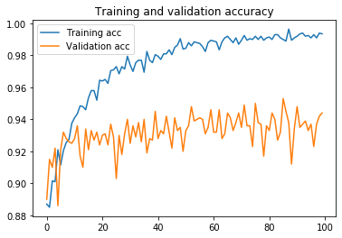

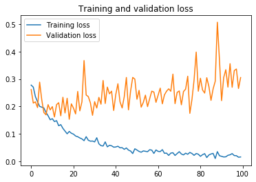

```python
acc = history.history['acc']
val_acc = history.history['val_acc']
loss = history.history['loss']
val_loss = history.history['val_loss']

epochs = range(len(acc))

plt.plot(epochs, acc, label='Training acc')
plt.plot(epochs, val_acc, label='Validation acc')
plt.title('Training and validation accuracy')
plt.legend()

plt.figure()

plt.plot(epochs, loss, label='Training loss')
plt.plot(epochs, val_loss, label='Validation loss')
plt.title('Training and validation loss')
plt.legend()

plt.show()
```

''' - 這些曲線看起來有很多的雜訊 - 通過以這些數量的指數移動平均值代替 - 每個損失和準確性來平滑它們 '''

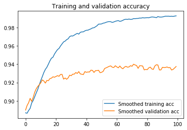

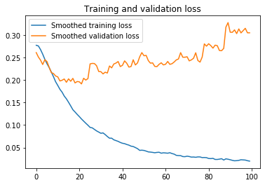

```python
def smooth_curve(points, factor=0.8):
  smoothed_points = []
  for point in points:
    if smoothed_points:
      previous = smoothed_points[-1]
      smoothed_points.append(previous * factor + point * (1 - factor))
    else:
      smoothed_points.append(point)
  return smoothed_points

plt.plot(epochs,
         smooth_curve(acc), label='Smoothed training acc')
plt.plot(epochs,
         smooth_curve(val_acc), label='Smoothed validation acc')
plt.title('Training and validation accuracy')
plt.legend()

plt.figure()

plt.plot(epochs,
         smooth_curve(loss), label='Smoothed training loss')
plt.plot(epochs,
         smooth_curve(val_loss), label='Smoothed validation loss')
plt.title('Training and validation loss')
plt.legend()

plt.show()
```

```python
test_generator = test_datagen.flow_from_directory(
        test_dir,
        target_size=(150, 150),
        batch_size=20,
        class_mode='binary')

test_loss, test_acc = model.evaluate_generator(test_generator, steps=50)
print('test acc:', test_acc)
```

```
Found 1000 images belonging to 2 classes.
test acc: 0.9349999916553497
```

參考文獻

- [fchollet: deep-learning-with-python-notebooks (原文)](https://github.com/fchollet/deep-learning-with-python-notebooks/blob/master/5.3-using-a-pretrained-convnet.ipynb)
- [Keras官網](http://keras.io/)

MIT License

Copyright (c) 2017 François Chollet

Permission is hereby granted, free of charge, to any person obtaining a copy of this software and associated documentation files (the "Software"), to deal in the Software without restriction, including without limitation the rights to use, copy, modify, merge, publish, distribute, sublicense, and/or sell copies of the Software, and to permit persons to whom the Software is furnished to do so, subject to the following conditions:

The above copyright notice and this permission notice shall be included in all copies or substantial portions of the Software.

THE SOFTWARE IS PROVIDED "AS IS", WITHOUT WARRANTY OF ANY KIND, EXPRESS OR IMPLIED, INCLUDING BUT NOT LIMITED TO THE WARRANTIES OF MERCHANTABILITY, FITNESS FOR A PARTICULAR PURPOSE AND NONINFRINGEMENT. IN NO EVENT SHALL THE AUTHORS OR COPYRIGHT HOLDERS BE LIABLE FOR ANY CLAIM, DAMAGES OR OTHER LIABILITY, WHETHER IN AN ACTION OF CONTRACT, TORT OR OTHERWISE, ARISING FROM, OUT OF OR IN CONNECTION WITH THE SOFTWARE OR THE USE OR OTHER DEALINGS IN THE SOFTWARE.